# Hands-on R 02

## Packages

- all packages are hosted on http://cran.r-project.org

### Installing packages

- Syntax: `install.packages('<pckg-name>')`

### Make package available to current R session

- Syntax: `library('<pckg-name>')`

```r
library('ggplot2') # load ggplot2 package
```

## Using `qplot` to create ‘quick plots’

- `qplot` creates a **scatterplot** from **two specified vectors**
  - **first input vector** = set of x values
  - **second input vector** = set of y values

We can use `rnorm()` to sample from the **standard normal distribution** + standard normal distribution = normal distribution with mean = 0 and stand. dev. (sd) = 1

```r
rnorm(n = 10, mean = 0, sd = 1)
```

```
##  [1]  0.2629971 -2.2263184  0.3362556  0.5239020 -0.7059630 -0.2052091
##  [7]  2.2804286 -0.6710068 -1.7518111 -0.5488824
```

```r
x_vect = rnorm(n = 1000, mean = 0, sd = 1) #create two vectors of random data using 'rnorm()'
y_vect = rnorm(n = 1000, mean = 0, sd = 1)
```

### Creating a **scatterplot** showing the *bivariate distribution* of `x_vect` and `y_vect`

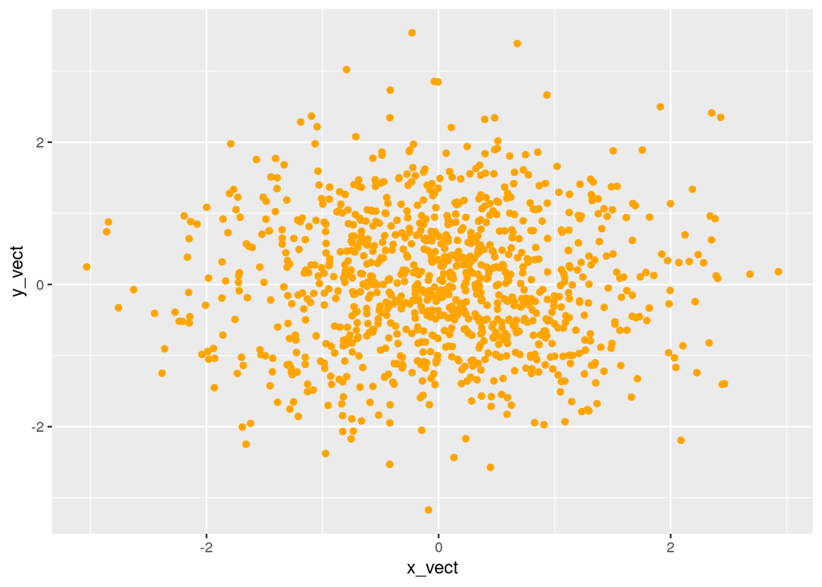

```r
qplot(x_vect, y_vect, color = I('orange'))
```

+ use Syntax `color= I('<color_name>')` to specify color of markers in scatterplot

### Creating a **histogram** showing the *univariate distribution* of `x_vect` or `y_vect`

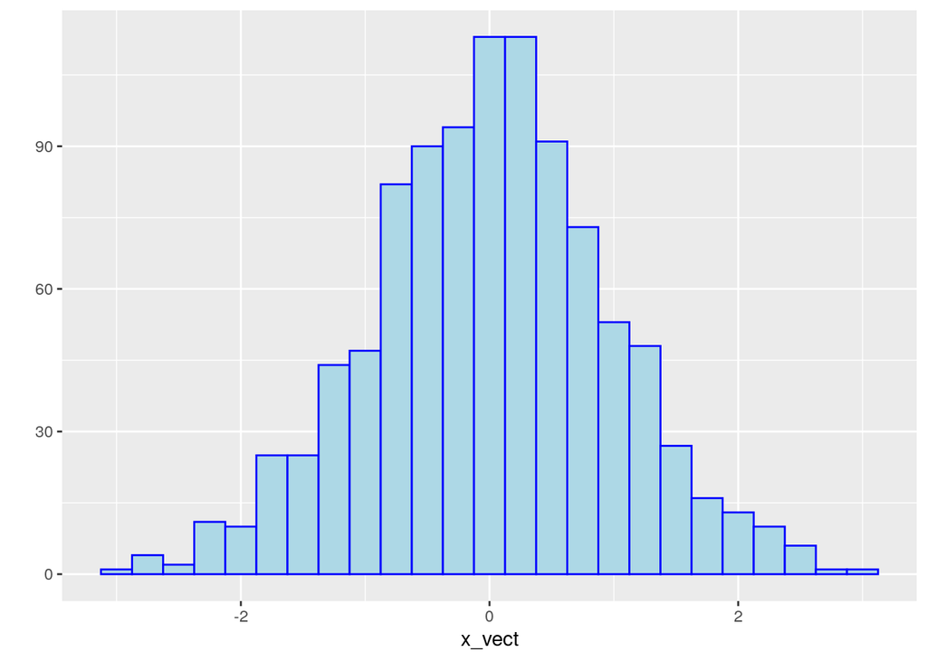

```r
qplot(x_vect, binwidth = 0.25, fill = I('lightblue'), color = I('blue'))
```

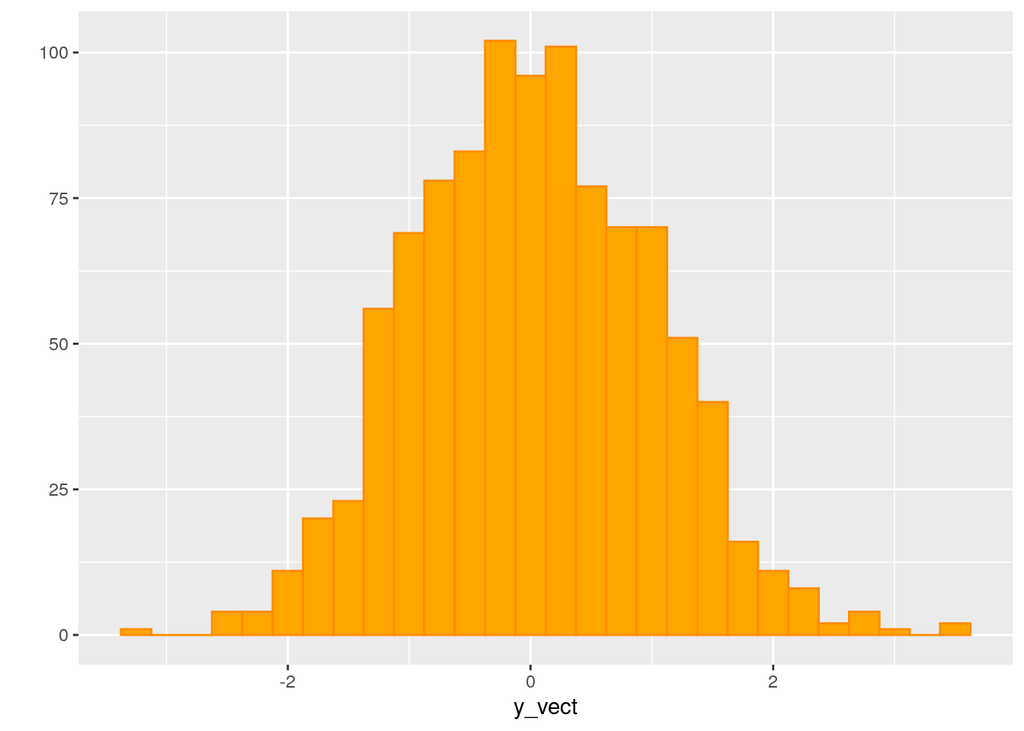

```r
qplot(y_vect, binwidth = 0.25, fill = I('orange'), color = I('darkorange'))
```

### Another scatterplot

```r
x_vect2 = c(-1, -0.8, -0.6, -0.4, -0.2, 0, 0.2, 0.4, 0.6, 0.8, 1)
y_vect2 = x_vect2^3 # raise to power of 3
```

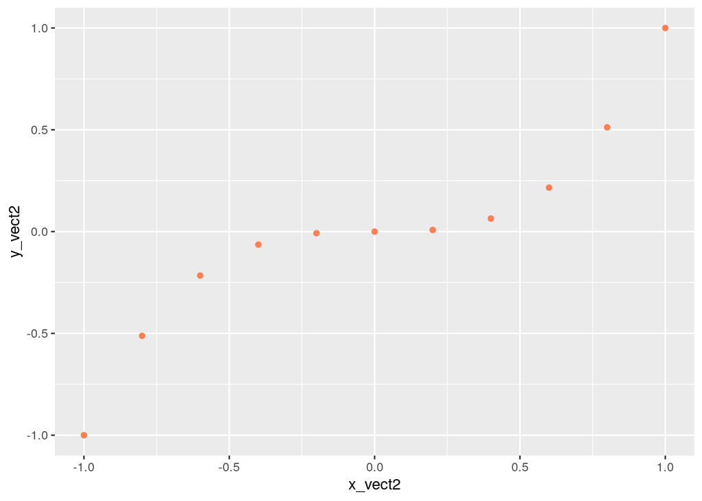

```r
qplot(x_vect2, y_vect2, color = I('coral'))
```

## Visualizing the distribution of rolling a die

- The function `roll()` simulates rolling two *fairly weighted* dice

```r
roll_fair = function(size = 2) {
  die = 1:6
  dice =  sample(die, size, replace = TRUE)
  sum(dice)
}
```

- the `replicate()` function allows us to **repeat** a command multiple times

```r
replicate
```

```
## function (n, expr, simplify = "array")
## sapply(integer(n), eval.parent(substitute(function(...) expr)),
##     simplify = simplify)
## <bytecode: 0x5586fc7139f0>
## <environment: namespace:base>
```

- use function `roll()` in combination with `replicate()`

```r
replicate(n = 10, roll_fair()) # replicates 'roll()' 10 times
```

```
##  [1]  8 11  7 10 11  8  4  2  9  7
```

### *Univariate distribution* of the sums of rolling **a pair of fair dice** 10000 times

- we can see that the distribution matches the distribution of sum values resulting from rolling a **fair** pair of dice

```
                                              (6,1)
                                        (5,1) (5,2) (6,2)
                                  (4,1) (4,2) (4,3) (5,3) (6,3)
                            (3,1) (3,2) (3,3) (3,4) (4,4) (5,4) (6,4)
                      (2,1) (2,2) (2,3) (2,4) (2,5) (3,5) (4,5) (5,5) (6,5)
                (1,1) (1,2) (1,3) (1,4) (1,5) (1,6) (2,6) (3,6) (4,6) (5,6) (6,6)
                _________________________________________________________________
                  2     3     4     5     6     7     8     9    10    11    12
                                              SUM
```

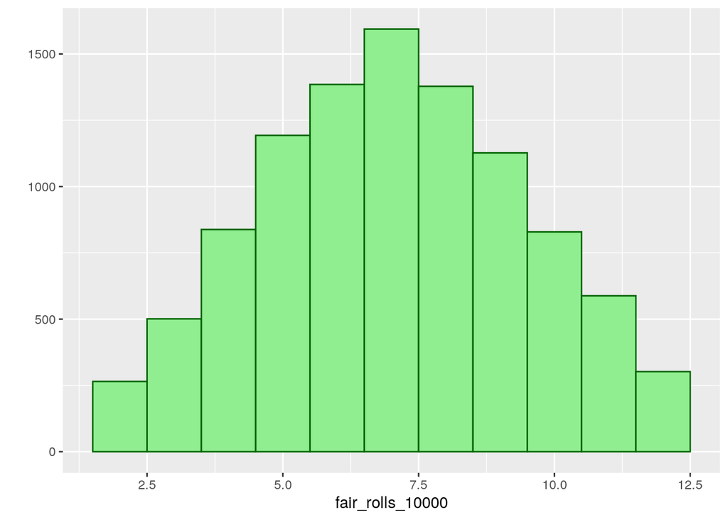

```r
fair_rolls_10000 = replicate(n = 10000, roll_fair())
qplot(fair_rolls_10000, binwidth = 1, fill= I('lightgreen'), color = I('darkgreen'))
```

```r
roll_unfair = function(size = 2) {
  die = 1:6
  dice =  sample(die, size, replace = TRUE, prob = c(1/8, 1/8, 1/8, 1/8, 1/8, 3/8)) # specify probabilities here
  sum(dice)
}
```

### *Univariate distribution* of the sums of rolling **a pair of weighted dice** 10000 times

- we can see that the distribution **does not match** the distribution of sum values resulting from rolling a **fair** pair of dice (see above)

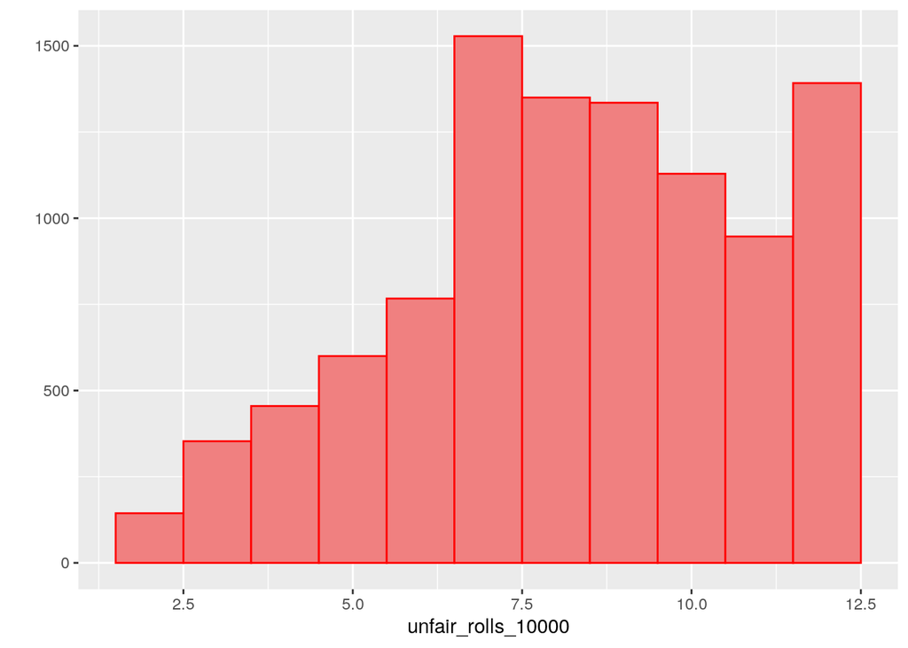

```r
unfair_rolls_10000 = replicate(n = 10000, roll_unfair())
qplot(unfair_rolls_10000, binwidth = 1, fill= I('lightcoral'), color = I('red'))
```